# Eighth Week: Text Analysis in R

To be, or not to be

Ali Gorji

2018-05-08 01:00:51

> با استفاده از بسته gutenberg داده های لازم را به دست آورید و به سوالات زیر پاسخ دهید.

۱. چارلز دیکنز نویسنده معروف انگلیسی بالغ بر چهارده رمان (چهارده و نیم) نوشته است. متن تمامی کتاب های او را دانلود کنید و سپس بیست لغت برتر استفاده شده را به صورت یک نمودار ستونی نمایش دهید. (طبیعتا باید ابتدا متن را پاکسازی کرده و stopping words را حذف نمایید تا به کلماتی که بار معنایی مشخصی منتقل می کنند برسید.)

```r
library(gutenbergr)
library(tm)
library(wordcloud2)
library(stringr)
library(dplyr)
library(highcharter)
library(tidytext)
library(tidyr)
library(ngram)
library(ggplot2)

gutenberg_works() %>% filter(author == "Dickens, Charles")
```

```
## # A tibble: 74 x 8
##    gutenberg_id title    author gutenberg_autho… language gutenberg_books…
##           <int> <chr>    <chr>             <int> <chr>    <chr>
##  1           46 A Chris… Dicke…               37 en       Christmas/Child…
##  2           98 A Tale … Dicke…               37 en       Historical Fict…
##  3          564 The Mys… Dicke…               37 en       Mystery Fiction
##  4          580 The Pic… Dicke…               37 en       Best Books Ever…
##  5          588 Master … Dicke…               37 en       <NA>
##  6          644 The Hau… Dicke…               37 en       Christmas
##  7          650 Picture… Dicke…               37 en       <NA>
##  8          653 "The Ch… Dicke…               37 en       <NA>
##  9          675 America… Dicke…               37 en       <NA>
## 10          678 The Cri… Dicke…               37 en       Children's Lite…
## # ... with 64 more rows, and 2 more variables: rights <chr>,
## #   has_text <lgl>
```

```r
ThePickwickPapers = gutenberg_download(580)
OliverTwist = gutenberg_download(730)
NicholasNickleby = gutenberg_download(967)
TheOldCuriosityShop = gutenberg_download(700)
BarnabyRudge = gutenberg_download(917)
MartinChuzzlewit = gutenberg_download(968)
DombeyandSon = gutenberg_download(821)
DavidCopperfield =gutenberg_download(766)
BleakHouse =gutenberg_download(1023)
HardTimes =gutenberg_download(786)
LittleDorrit =gutenberg_download(963)
ATaleofTwoCities = gutenberg_download(98)
GreatExpectations = gutenberg_download(1400)
OurMutualFriend = gutenberg_download(883)
TheMysteryofEdwinDrood = gutenberg_download(564)

text = c(ThePickwickPapers$text, OliverTwist$text, NicholasNickleby$text, TheOldCuriosityShop$text, BarnabyRudge$text, MartinChuzzlewit$text, DombeyandSon$text, DavidCopperfield$text, BleakHouse$text, HardTimes$text, LittleDorrit$text, ATaleofTwoCities$text, GreatExpectations$text, GreatExpectations$text, OurMutualFriend$text, TheMysteryofEdwinDrood$text) %>%tolower()

stopWords = stopwords() %>% c("mr", "mrs", "sir", "well", "doctor", "miss", "will", "might", "must")
removeStopWords = function(inputText){
  cleaned = tolower(inputText)
  for(word in stopWords){
    word = paste("\\b",word,"\\b",sep = "")
    cleaned = str_remove_all(cleaned, word)
  }
  cleaned = str_replace_all(cleaned, "[[:punct:]]", " ")
  for(word in c("s", "d")){
    word = paste("\\b",word,"\\b",sep = "")
    cleaned = str_remove_all(cleaned, word)
  }
  return(cleaned)
}
full_text = removeStopWords(text)

makeWordFrame = function(inputText){
  word_list <- str_split(inputText, "\\s+") %>% unlist()
  word.frame <- word_list[word_list!=""] %>% table() %>% as.data.frame(stringsAsFactors = F) %>% arrange(desc(Freq)) %>% return()
}
word.frame = makeWordFrame(full_text)
hchart(word.frame %>% top_n(20) %>% select(Word = c(1), Frequency = Freq), type = "column", hcaes(Word, Frequency))
```

[interactive chart not shown]

۲. ابر لغات ۲۰۰ کلمه پرتکرار در رمان های چارلز دیکنز را رسم نمایید. این کار را با بسته wordcloud2 انجام دهید. برای دانلود می توانید به لینک زیر مراجعه کنید.

https://github.com/Lchiffon/wordcloud2

با استفاده از عکسی که در ابتدا متن آمده ابر لغاتی مانند شکل زیر رسم کنید. (راهنمایی: از ورودی figpath در دستور wordcloud2 استفاده نمایید.مثالی در زیر آورده شده است.)

```r
wordcloud2(word.frame %>% head(200), size = 0.4, figPath = "images/Dickens.jpg", color = "black")
```

[interactive chart not shown]

***

۳. اسم پنج شخصیت اصلی در هر رمان دیکنز را استخراج کنید و با نموداری تعداد دفعات تکرار شده بر حسب رمان را رسم نمایید. (مانند مثال کلاس در رسم اسامی شخصیت ها در سری هر پاتر)

برای مشخص کردن نام شخصیت های اصلی از دو فرض استفاده کردیم؛ نام اشخاص با حروف بزرگ شروع می شوند، شخصیت های اصلی بیشتر نامشان در داستان آورده شده است. بر این اساس نام شخصیت های اصلی کتاب های مختلف را بر اساس میزان تکرارشان در نمودار های زیر مشاهده می کنید:

```r
ThePickwickPapersCharacters = grep("[A-Z]", str_replace_all(ThePickwickPapers$text, "[[:punct:]]", " ") %>%  str_split("\\s+") %>% unlist(), value = T) %>% table() %>%  as.data.frame(stringsAsFactors = F) %>% select(Name = c(1), Freq) %>% mutate(LowCaseName = tolower(Name)) %>% filter(!(LowCaseName %in% stopWords)) %>% arrange(desc(Freq)) %>% select(Name, Freq) %>% head(5)
hchart(ThePickwickPapersCharacters, type = "pie", hcaes(x = Name, y = Freq))
```

[interactive chart not shown]

```r
OliverTwistCharacters = grep("[A-Z]", str_replace_all(OliverTwist$text, "[[:punct:]]", " ") %>%  str_split("\\s+") %>% unlist(), value = T) %>% table() %>%  as.data.frame(stringsAsFactors = F) %>% select(Name = c(1), Freq) %>% mutate(LowCaseName = tolower(Name)) %>% filter(!(LowCaseName %in% stopWords)) %>% arrange(desc(Freq)) %>% select(Name, Freq) %>% head(5)
hchart(OliverTwistCharacters, type = "pie", hcaes(x = Name, y = Freq))
```

[interactive chart not shown]

```r
NicholasNicklebyCharacters = grep("[A-Z]", str_replace_all(NicholasNickleby$text, "[[:punct:]]", " ") %>%  str_split("\\s+") %>% unlist(), value = T) %>% table() %>%  as.data.frame(stringsAsFactors = F) %>% select(Name = c(1), Freq) %>% mutate(LowCaseName = tolower(Name)) %>% filter(!(LowCaseName %in% stopWords)) %>% arrange(desc(Freq)) %>% select(Name, Freq) %>% head(5)
hchart(NicholasNicklebyCharacters, type = "pie", hcaes(x = Name, y = Freq))
```

[interactive chart not shown]

```r
TheOldCuriosityShopCharacters = grep("[A-Z]", str_replace_all(TheOldCuriosityShop$text, "[[:punct:]]", " ") %>%  str_split("\\s+") %>% unlist(), value = T) %>% table() %>%  as.data.frame(stringsAsFactors = F) %>% select(Name = c(1), Freq) %>% mutate(LowCaseName = tolower(Name)) %>% filter(!(LowCaseName %in% stopWords)) %>% arrange(desc(Freq)) %>% select(Name, Freq) %>% head(5)
hchart(TheOldCuriosityShopCharacters, type = "pie", hcaes(x = Name, y = Freq))
```

[interactive chart not shown]

```r
BarnabyRudgeCharacters = grep("[A-Z]", str_replace_all(BarnabyRudge$text, "[[:punct:]]", " ") %>%  str_split("\\s+") %>% unlist(), value = T) %>% table() %>%  as.data.frame(stringsAsFactors = F) %>% select(Name = c(1), Freq) %>% mutate(LowCaseName = tolower(Name)) %>% filter(!(LowCaseName %in% stopWords)) %>% arrange(desc(Freq)) %>% select(Name, Freq) %>% head(5)
hchart(BarnabyRudgeCharacters, type = "pie", hcaes(x = Name, y = Freq))
```

[interactive chart not shown]

```r
MartinChuzzlewitCharacters = grep("[A-Z]", str_replace_all(MartinChuzzlewit$text, "[[:punct:]]", " ") %>%  str_split("\\s+") %>% unlist(), value = T) %>% table() %>%  as.data.frame(stringsAsFactors = F) %>% select(Name = c(1), Freq) %>% mutate(LowCaseName = tolower(Name)) %>% filter(!(LowCaseName %in% stopWords)) %>% arrange(desc(Freq)) %>% select(Name, Freq) %>% head(5)
hchart(MartinChuzzlewitCharacters, type = "pie", hcaes(x = Name, y = Freq))
```

[interactive chart not shown]

```r
DombeyandSonCharacters = grep("[A-Z]", str_replace_all(DombeyandSon$text, "[[:punct:]]", " ") %>%  str_split("\\s+") %>% unlist(), value = T) %>% table() %>%  as.data.frame(stringsAsFactors = F) %>% select(Name = c(1), Freq) %>% mutate(LowCaseName = tolower(Name)) %>% filter(!(LowCaseName %in% stopWords)) %>% arrange(desc(Freq)) %>% select(Name, Freq) %>% head(5)
hchart(DombeyandSonCharacters, type = "pie", hcaes(x = Name, y = Freq))
```

[interactive chart not shown]

```r
DavidCopperfieldCharacters = grep("[A-Z]", str_replace_all(DavidCopperfield$text, "[[:punct:]]", " ") %>%  str_split("\\s+") %>% unlist(), value = T) %>% table() %>%  as.data.frame(stringsAsFactors = F) %>% select(Name = c(1), Freq) %>% mutate(LowCaseName = tolower(Name)) %>% filter(!(LowCaseName %in% stopWords)) %>% arrange(desc(Freq)) %>% select(Name, Freq) %>% head(5)
hchart(DavidCopperfieldCharacters, type = "pie", hcaes(x = Name, y = Freq))
```

[interactive chart not shown]

```r
BleakHouseCharacters = grep("[A-Z]", str_replace_all(BleakHouse$text, "[[:punct:]]", " ") %>%  str_split("\\s+") %>% unlist(), value = T) %>% table() %>%  as.data.frame(stringsAsFactors = F) %>% select(Name = c(1), Freq) %>% mutate(LowCaseName = tolower(Name)) %>% filter(!(LowCaseName %in% stopWords)) %>% arrange(desc(Freq)) %>% select(Name, Freq) %>% head(5)
hchart(BleakHouseCharacters, type = "pie", hcaes(x = Name, y = Freq))
```

[interactive chart not shown]

```r
HardTimesCharacters = grep("[A-Z]", str_replace_all(HardTimes$text, "[[:punct:]]", " ") %>%  str_split("\\s+") %>% unlist(), value = T) %>% table() %>%  as.data.frame(stringsAsFactors = F) %>% select(Name = c(1), Freq) %>% mutate(LowCaseName = tolower(Name)) %>% filter(!(LowCaseName %in% stopWords)) %>% arrange(desc(Freq)) %>% select(Name, Freq) %>% head(5)
hchart(HardTimesCharacters, type = "pie", hcaes(x = Name, y = Freq))
```

[interactive chart not shown]

```r
LittleDorritCharacters = grep("[A-Z]", str_replace_all(LittleDorrit$text, "[[:punct:]]", " ") %>%  str_split("\\s+") %>% unlist(), value = T) %>% table() %>%  as.data.frame(stringsAsFactors = F) %>% select(Name = c(1), Freq) %>% mutate(LowCaseName = tolower(Name)) %>% filter(!(LowCaseName %in% stopWords)) %>% arrange(desc(Freq)) %>% select(Name, Freq) %>% head(5)
hchart(LittleDorritCharacters, type = "pie", hcaes(x = Name, y = Freq))
```

[interactive chart not shown]

```r
ATaleofTwoCitiesCharacters = grep("[A-Z]", str_replace_all(ATaleofTwoCities$text, "[[:punct:]]", " ") %>%  str_split("\\s+") %>% unlist(), value = T) %>% table() %>%  as.data.frame(stringsAsFactors = F) %>% select(Name = c(1), Freq) %>% mutate(LowCaseName = tolower(Name)) %>% filter(!(LowCaseName %in% stopWords)) %>% arrange(desc(Freq)) %>% select(Name, Freq) %>% head(5)
hchart(ATaleofTwoCitiesCharacters, type = "pie", hcaes(x = Name, y = Freq))
```

[interactive chart not shown]

```r
GreatExpectationsCharacters = grep("[A-Z]", str_replace_all(GreatExpectations$text, "[[:punct:]]", " ") %>%  str_split("\\s+") %>% unlist(), value = T) %>% table() %>%  as.data.frame(stringsAsFactors = F) %>% select(Name = c(1), Freq) %>% mutate(LowCaseName = tolower(Name)) %>% filter(!(LowCaseName %in% stopWords)) %>% arrange(desc(Freq)) %>% select(Name, Freq) %>% head(5)
hchart(GreatExpectationsCharacters, type = "pie", hcaes(x = Name, y = Freq))
```

[interactive chart not shown]

```r
OurMutualFriendCharacters = grep("[A-Z]", str_replace_all(OurMutualFriend$text, "[[:punct:]]", " ") %>%  str_split("\\s+") %>% unlist(), value = T) %>% table() %>%  as.data.frame(stringsAsFactors = F) %>% select(Name = c(1), Freq) %>% mutate(LowCaseName = tolower(Name)) %>% filter(!(LowCaseName %in% stopWords)) %>% arrange(desc(Freq)) %>% select(Name, Freq) %>% head(5)
hchart(OurMutualFriendCharacters, type = "pie", hcaes(x = Name, y = Freq))
```

[interactive chart not shown]

```r
TheMysteryofEdwinDroodCharacters = grep("[A-Z]", str_replace_all(TheMysteryofEdwinDrood$text, "[[:punct:]]", " ") %>%  str_split("\\s+") %>% unlist(), value = T) %>% table() %>%  as.data.frame(stringsAsFactors = F) %>% select(Name = c(1), Freq) %>% mutate(LowCaseName = tolower(Name)) %>% filter(!(LowCaseName %in% stopWords)) %>% arrange(desc(Freq)) %>% select(Name, Freq) %>% head(5)
hchart(TheMysteryofEdwinDroodCharacters, type = "pie", hcaes(x = Name, y = Freq))
```

[interactive chart not shown]

۴. در بسته tidytext داده ایی به نام sentiments وجود دارد که فضای احساسی لغات را مشخص می نماید. با استفاده از این داده نمودار ۲۰ لغت برتر negative و ۲۰ لغت برتر positive را در کنار هم رسم نمایید. با استفاده از این نمودار فضای حاکم بر داستان چگونه ارزیابی می کنید؟ (به طور مثال برای کتاب داستان دو شهر فضای احساسی داستان به ترتیب تکرر در نمودار زیر قابل مشاهده است.)

در دو نمودار اول به ترتیب بیست لغت مثبت و منفی پرتکرار را مشخص می کنم و سپس به ازای هر کتاب نمودار فضای حاکم بر داستان را بررسی می کنیم.

```r
addSentiment = function(wordFrame){
  wordFrame %>% select(word = c(1), Freq) %>% full_join(sentiments) %>% filter(!is.na(sentiment) & !is.na(Freq)) %>% select(word, Freq, sentiment) %>% return()
}
countSentiment = function(wordFrame){
  sentimentAdded <- addSentiment(wordFrame)
  sentimentAdded %>% group_by(sentiment) %>% summarise(count = sum(Freq)) %>% arrange(desc(count)) %>% return()
}
full_stories_added_Sentiment = addSentiment(word.frame)
```

```r
hchart(full_stories_added_Sentiment %>% filter(sentiment == "positive") %>% top_n(20), type = "bar", hcaes(x = word, y= Freq))
```

[interactive chart not shown]

```r
hchart(full_stories_added_Sentiment %>% filter(sentiment == "negative") %>% top_n(20), type = "bar", hcaes(x = word, y= Freq))
```

[interactive chart not shown]

```r
ThePickwickPapersSentiment <- ThePickwickPapers$text %>% removeStopWords() %>% makeWordFrame() %>%  countSentiment()
```

```r
hchart(ThePickwickPapersSentiment, type = "bar", hcaes(x = sentiment, y= count)) %>% hc_add_theme(hc_theme_handdrawn())
```

[interactive chart not shown]

```r
OliverTwistSentiment <- OliverTwist$text %>% removeStopWords() %>% makeWordFrame() %>%  countSentiment()
```

```r
hchart(OliverTwistSentiment, type = "bar", hcaes(x = sentiment, y= count)) %>% hc_add_theme(hc_theme_handdrawn())
```

[interactive chart not shown]

```r
NicholasNicklebySentiment <- NicholasNickleby$text %>% removeStopWords() %>% makeWordFrame() %>%  countSentiment()
```

```r
hchart(NicholasNicklebySentiment, type = "bar", hcaes(x = sentiment, y= count)) %>% hc_add_theme(hc_theme_handdrawn())
```

[interactive chart not shown]

```r
TheOldCuriosityShopSentiment <- TheOldCuriosityShop$text %>% removeStopWords() %>% makeWordFrame() %>%  countSentiment()
```

```r
hchart(TheOldCuriosityShopSentiment, type = "bar", hcaes(x = sentiment, y= count)) %>% hc_add_theme(hc_theme_handdrawn())
```

[interactive chart not shown]

```r
BarnabyRudgeSentiment <- BarnabyRudge$text %>% removeStopWords() %>% makeWordFrame() %>%  countSentiment()
```

```r
hchart(BarnabyRudgeSentiment, type = "bar", hcaes(x = sentiment, y= count)) %>% hc_add_theme(hc_theme_handdrawn())
```

[interactive chart not shown]

```r
MartinChuzzlewitSentiment <- MartinChuzzlewit$text %>% removeStopWords() %>% makeWordFrame() %>%  countSentiment()
```

```r
hchart(MartinChuzzlewitSentiment, type = "bar", hcaes(x = sentiment, y= count)) %>% hc_add_theme(hc_theme_handdrawn())
```

[interactive chart not shown]

```r
DombeyandSonSentiment <- DombeyandSon$text %>% removeStopWords() %>% makeWordFrame() %>%  countSentiment()
```

```r
hchart(DombeyandSonSentiment, type = "bar", hcaes(x = sentiment, y= count)) %>% hc_add_theme(hc_theme_handdrawn())
```

[interactive chart not shown]

```r
DavidCopperfieldSentiment <- DavidCopperfield$text %>% removeStopWords() %>% makeWordFrame() %>%  countSentiment()
```

```r
hchart(DavidCopperfieldSentiment, type = "bar", hcaes(x = sentiment, y= count)) %>% hc_add_theme(hc_theme_handdrawn())
```

[interactive chart not shown]

```r
BleakHouseSentiment <- BleakHouse$text %>% removeStopWords() %>% makeWordFrame() %>%  countSentiment()
```

```r
hchart(BleakHouseSentiment, type = "bar", hcaes(x = sentiment, y= count)) %>% hc_add_theme(hc_theme_handdrawn())
```

[interactive chart not shown]

```r
HardTimesSentiment <- HardTimes$text %>% removeStopWords() %>% makeWordFrame() %>%  countSentiment()
```

```r
hchart(HardTimesSentiment, type = "bar", hcaes(x = sentiment, y= count)) %>% hc_add_theme(hc_theme_handdrawn())
```

[interactive chart not shown]

```r
LittleDorritSentiment <- LittleDorrit$text %>% removeStopWords() %>% makeWordFrame() %>%  countSentiment()
```

```r
hchart(LittleDorritSentiment, type = "bar", hcaes(x = sentiment, y= count)) %>% hc_add_theme(hc_theme_handdrawn())
```

[interactive chart not shown]

```r
ATaleofTwoCitiesSentiment <- ATaleofTwoCities$text %>% removeStopWords() %>% makeWordFrame() %>%  countSentiment()
```

```r
hchart(ATaleofTwoCitiesSentiment, type = "bar", hcaes(x = sentiment, y= count)) %>% hc_add_theme(hc_theme_handdrawn())
```

[interactive chart not shown]

```r
GreatExpectationsSentiment <- GreatExpectations$text %>% removeStopWords() %>% makeWordFrame() %>%  countSentiment()
```

```r
hchart(GreatExpectationsSentiment, type = "bar", hcaes(x = sentiment, y= count)) %>% hc_add_theme(hc_theme_handdrawn())
```

[interactive chart not shown]

```r
OurMutualFriendSentiment <- OurMutualFriend$text %>% removeStopWords() %>% makeWordFrame() %>%  countSentiment()
```

```r
hchart(OurMutualFriendSentiment, type = "bar", hcaes(x = sentiment, y= count)) %>% hc_add_theme(hc_theme_handdrawn())
```

[interactive chart not shown]

```r
TheMysteryofEdwinDroodSentiment <- TheMysteryofEdwinDrood$text %>% removeStopWords() %>% makeWordFrame() %>%  countSentiment()
```

```r
hchart(TheMysteryofEdwinDroodSentiment, type = "bar", hcaes(x = sentiment, y= count)) %>% hc_add_theme(hc_theme_handdrawn())
```

[interactive chart not shown]

۵. متن داستان بینوایان را به ۲۰۰ قسمت مساوی تقسیم کنید. برای هر قسمت تعداد لغات positive و negative را حساب کنید و سپس این دو سری زمانی را در کنار هم برای مشاهده فضای احساسی داستان رسم نمایید.

```r
LesMiserable = gutenberg_download(135)
cleaned_LesMiserable = removeStopWords(LesMiserable$text)
lesmiserable.frame = makeWordFrame(cleaned_LesMiserable)
chunkLength = ceiling(length(cleaned_LesMiserable)/200)
chunkedLesmiserable = split(cleaned_LesMiserable, ceiling((seq(length(cleaned_LesMiserable)))/ chunkLength))
positivity = c()
negativity = c()
for (chunk in chunkedLesmiserable) {
  chunk.frame = makeWordFrame(chunk)
  positivity = c(positivity, (countSentiment(chunk.frame) %>% filter(sentiment == "positive"))$count[1])
  negativity = c(negativity, (countSentiment(chunk.frame) %>% filter(sentiment == "negative"))$count[1])
}

highchart() %>% hc_add_series(data = data.frame(chunk = 1:length(positivity),  positivity), type = "line", hcaes(x=chunk, y=positivity), name = "Positivity") %>% hc_add_series(data = data.frame(chunk = 1:length(negativity),  negativity), type = "line", hcaes(x=chunk, y=negativity), name = "Negativity")
```

[interactive chart not shown]

۶. ابتدا ترکیبات دوتایی کلماتی که پشت سر هم می آیند را استخراج کنید و سپس نمودار ۳۰ جفت لغت پرتکرار را رسم نمایید.

```r
twoGrams = data.frame(text = text) %>% unnest_tokens(bigram, text, token = "ngrams", n = 2)
cleanedTwoGrams = twoGrams %>% separate(bigram, c("First", "Second"), sep = " ") %>% filter(!(First %in% stopWords) & !(Second %in% stopWords))

countedTwoGrams = cleanedTwoGrams %>% group_by(First, Second) %>% summarise(count = n()) %>% arrange(desc(count)) %>% head(30) %>% mutate(word = paste(First, Second)) %>% select(word, count)
hchart(countedTwoGrams, "bar", hcaes(x = word, y = count))
```

[interactive chart not shown]

۷. جفت کلماتی که با she و یا he آغاز می شوند را استخراج کنید. بیست فعل پرتکراری که زنان و مردان در داستان های دیکنز انجام می دهند را استخراج کنید و نمودار آن را رسم نمایید.

```r
sheVerbs = twoGrams %>% separate(bigram, c("First", "Second"), sep = " ") %>% filter(First == "she" & !(Second %in% stopWords)) %>% group_by(Second) %>% summarise(count = n()) %>% select(verb = Second, count) %>% arrange(desc(count)) %>%  head(20)
heVerbs = twoGrams %>% separate(bigram, c("First", "Second"), sep = " ") %>% filter(First == "he" & !(Second %in% stopWords)) %>% group_by(Second) %>% summarise(count = n()) %>% select(verb = Second, count) %>% arrange(desc(count)) %>%  head(20)
hchart(sheVerbs, "bar", hcaes(x = verb, y = count))
```

[interactive chart not shown]

```r
hchart(heVerbs, "bar", hcaes(x = verb, y = count))
```

[interactive chart not shown]

۸. برای کتاب های دیکنز ابتدا هر فصل را جدا کنید. سپی برای هر فصل 1-gram, 2-gram را استخراج کنید. آیا توزیع N-gram در کارهای دیکنز یکسان است؟ با رسم نمودار هم این موضوع را بررسی کنید.

با توجه به اینکه منظور سوال به طور کاملی بیان نشده بود برداشت بنده از این سوال به دست آوردن توزیع تکرار کلمات در بخش های مختلف و مقایسه آن ها بود. همینطور به دلیل مسائل پردازشی و یکسان بودن عملیات برای کتاب های مختلف، سه سوال آخر بر روی یکی از کتاب های نویسنده ها پردازش را انجام می دهیم و از در نظر گرفتن سایر کتاب ها می پرهیزیم.

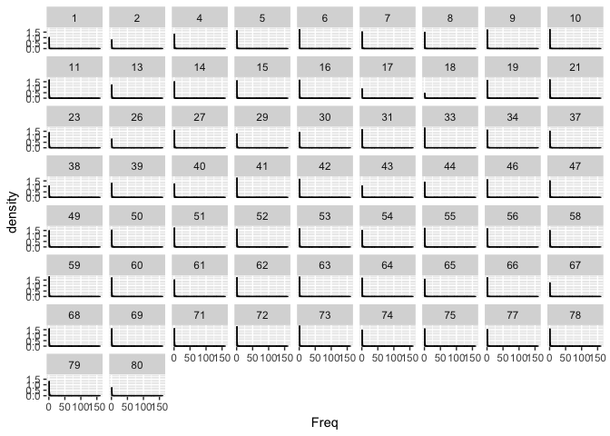

```r
ThePickwickPapersChapters = str_split(paste(removeStopWords(ThePickwickPapers$text)[210:length(ThePickwickPapers$text)], collapse = ' '),"\\bchapter\\b")[[1]]
DickensOneGrams = data.frame()
DickensTwoGrams = data.frame()
for(i in 1:length(ThePickwickPapersChapters)){
  chapter = ThePickwickPapersChapters[i]
  if(nchar(chapter)<500)
    next()
  tempOneGrams = data.frame(text = chapter) %>% unnest_tokens(word, text, token = "ngrams", n = 1) %>% table() %>% as.data.frame(stringsAsFactors = F)
  tempTwoGrams = data.frame(text = chapter) %>% unnest_tokens(word, text, token = "ngrams", n = 2) %>% table() %>% as.data.frame(stringsAsFactors = F)
  tempOneGrams$chapter <- i
  tempTwoGrams$chapter <- i
  DickensOneGrams = rbind(DickensOneGrams, tempOneGrams)
  DickensTwoGrams = rbind(DickensTwoGrams, tempTwoGrams)
}
ggplot(DickensOneGrams) + geom_density(aes(Freq)) + facet_wrap(~chapter)
```

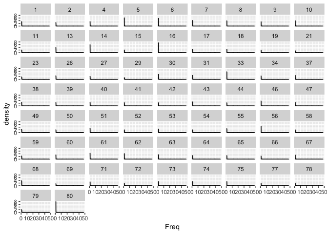

```r
ggplot(DickensTwoGrams) + geom_density(aes(Freq)) + facet_wrap(~chapter)
```

```r
summary(aov(Freq ~ as.factor(chapter), data = DickensOneGrams))
```

```
##                       Df  Sum Sq Mean Sq F value Pr(>F)
## as.factor(chapter)    64    3164   49.44   3.781 <2e-16 ***
## Residuals          76833 1004533   13.07
## ---
## Signif. codes:  0 '***' 0.001 '**' 0.01 '*' 0.05 '.' 0.1 ' ' 1
```

```r
summary(aov(Freq ~ as.factor(chapter), data = DickensTwoGrams))
```

```
##                        Df Sum Sq Mean Sq F value  Pr(>F)
## as.factor(chapter)     64     87  1.3542   2.258 3.7e-08 ***
## Residuals          139388  83584  0.5997
## ---
## Signif. codes:  0 '***' 0.001 '**' 0.01 '*' 0.05 '.' 0.1 ' ' 1
```

با توجه به دو تست آنوا زده شده برای n-gram به نظر می رسد توزیع نمی تواند در تمامی فصل ها یکسان باشد. اما اگر خطا های موجود را در نظر نگیریم، با توجه به نمودار های به دست آمده به نظر می رسد تا حد خوبی می توانیم شباهت در توزیع تکرار کلمات در فصل های مختلف ببینیم.

۹. برای آثار ارنست همینگوی نیز تمرین ۸ را تکرار کنید. آیا بین آثار توزیع n-grams در بین آثار این دو نویسنده یکسان است؟

به دلیل عدم وجود کتاب های همینگوی در کتابخانه معرفی شده، از کتاب اما نوشته جین آستین برای بررسی در این بخش استفاده می کنیم.

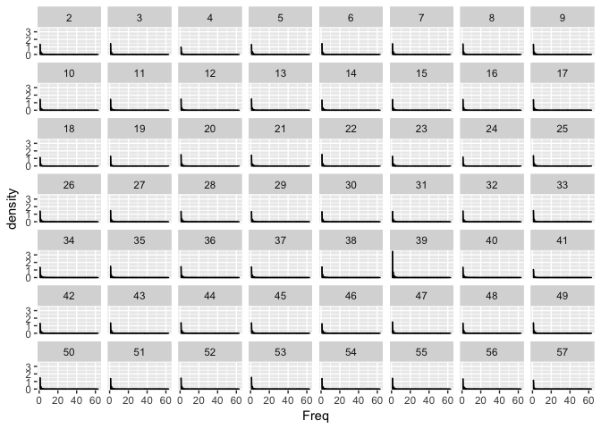

```r
Emma = gutenberg_download(158)
EmmaChapters = str_split(paste(removeStopWords(Emma$text), collapse = ' '),"\\bchapter\\b")[[1]]
AustenOneGrams = data.frame()
AustenTwoGrams = data.frame()
for(i in 1:length(EmmaChapters)){
  chapter = EmmaChapters[i]
  if(nchar(chapter)<500)
    next()
  tempOneGrams = data.frame(text = chapter) %>% unnest_tokens(word, text, token = "ngrams", n = 1) %>% table() %>% as.data.frame(stringsAsFactors = F)
  tempTwoGrams = data.frame(text = chapter) %>% unnest_tokens(word, text, token = "ngrams", n = 2) %>% table() %>% as.data.frame(stringsAsFactors = F)
  tempOneGrams$chapter <- i
  tempTwoGrams$chapter <- i
  AustenOneGrams = rbind(AustenOneGrams, tempOneGrams)
  AustenTwoGrams = rbind(AustenTwoGrams, tempTwoGrams)
}
ggplot(AustenOneGrams) + geom_density(aes(Freq)) + facet_wrap(~chapter)
```

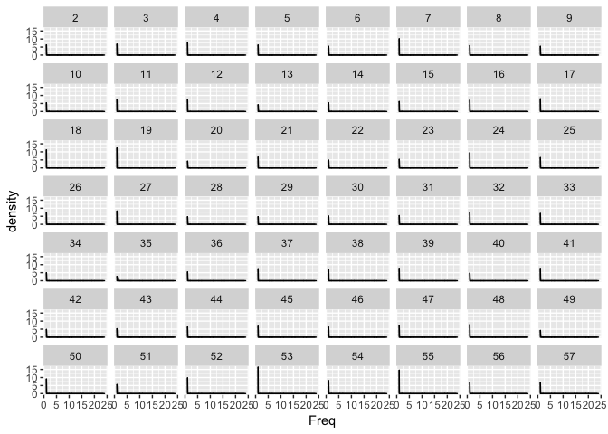

```r
ggplot(AustenTwoGrams) + geom_density(aes(Freq)) + facet_wrap(~chapter)
```

```r
summary(aov(Freq ~ as.factor(chapter), data = AustenOneGrams))
```

```
##                       Df Sum Sq Mean Sq F value Pr(>F)
## as.factor(chapter)    55   1754   31.89   8.169 <2e-16 ***
## Residuals          38118 148793    3.90
## ---
## Signif. codes:  0 '***' 0.001 '**' 0.01 '*' 0.05 '.' 0.1 ' ' 1
```

```r
summary(aov(Freq ~ as.factor(chapter), data = AustenTwoGrams))
```

```
##                       Df Sum Sq Mean Sq F value   Pr(>F)
## as.factor(chapter)    55     10 0.17490   2.067 5.78e-06 ***
## Residuals          66382   5617 0.08462
## ---
## Signif. codes:  0 '***' 0.001 '**' 0.01 '*' 0.05 '.' 0.1 ' ' 1
```

حال برای هر دو کتاب به عنوان نماینده ای از آثار هر یک از نویسنده ها، توزیع 1-gram و 2-gram برای کل کتاب را در نظر می گیریم و با هم مقایسه می کنیم.

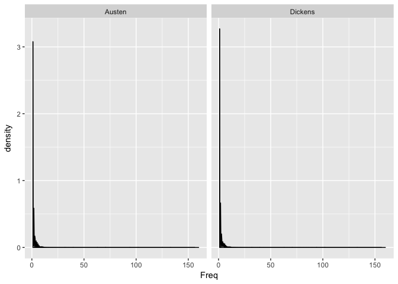

```r
AustenOneGrams$Author <- "Austen"
AustenTwoGrams$Author <- "Austen"
DickensOneGrams$Author <- "Dickens"
DickensTwoGrams$Author <- "Dickens"
oneGrams = rbind(AustenOneGrams, DickensOneGrams)
twoGrams = rbind(AustenTwoGrams, DickensTwoGrams)
ggplot(oneGrams) + geom_density(aes(Freq)) + facet_wrap(~Author)
```

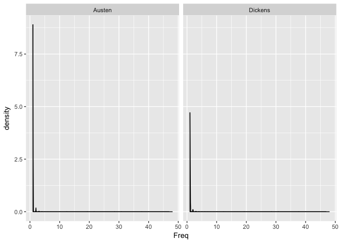

```r
ggplot(twoGrams) + geom_density(aes(Freq)) + facet_wrap(~Author)
```

```r
t.test(Freq ~ Author, oneGrams)
```

```
##
##  Welch Two Sample t-test
##
## data:  Freq by Author
## t = -9.8962, df = 114000, p-value < 2.2e-16
## alternative hypothesis: true difference in means is not equal to 0
## 95 percent confidence interval:
##  -0.1961563 -0.1313018
## sample estimates:
##  mean in group Austen mean in group Dickens
##              1.795568              1.959297
```

```r
t.test(Freq ~ Author, twoGrams)
```

```
##
##  Welch Two Sample t-test
##
## data:  Freq by Author
## t = -20.784, df = 197870, p-value < 2.2e-16
## alternative hypothesis: true difference in means is not equal to 0
## 95 percent confidence interval:
##  -0.05371380 -0.04445635
## sample estimates:
##  mean in group Austen mean in group Dickens
##              1.030856              1.079941
```

نتیجه تست نشان می دهد اختلاف فاحشی بین توزیع هم در 1-gram و هم در 2-gram بین هر دو نویسنده وجود دارد و نمودار هم تا حدی این مسئله را بیان می کند.

۱۰. بر اساس دادهایی که در تمرین ۸ و ۹ از آثار دو نویسنده به دست آوردید و با استفاده از N-gram ها یک مدل لاجستیک برای تشخیص صاحب اثر بسازید. خطای مدل چقدر است؟ برای یادگیری مدل از کتاب کتاب الیور تویست اثر دیکنز و کتاب پیرمرد و دریا استفاده نکنید. پس از ساختن مدل برای تست کردن فصل های این کتابها را به عنوان داده ورودی به مدل بدهید. خطای تشخیص چقدر است؟

با برداشتی که در سوالات قبل از توزیع داشتیم، مدل را بر اساس فرکانس استفاده از کلمات برتر بر اساس رنکشان در نظر می گیریم. به این صورت که فرکانس بیست کلمه پر استفاده برای هر چپتر را برای یادگیری استفاده می کنیم. فصل دهم هر دو کتاب در نظر گرفته شده را در داده هایمان لحاظ نمی کنیم و در نهایت از آن ها برای تست مدلمان استفاده می کنیم.

```r
library(h2o)
h2o.init()
```

```
##  Connection successful!
##
## R is connected to the H2O cluster:
##     H2O cluster uptime:         1 hours 50 minutes
##     H2O cluster timezone:       Asia/Tehran
##     H2O data parsing timezone:  UTC
##     H2O cluster version:        3.19.0.4257
##     H2O cluster version age:    29 days
##     H2O cluster name:           H2O_started_from_R_ali_awa583
##     H2O cluster total nodes:    1
##     H2O cluster total memory:   1.65 GB
##     H2O cluster total cores:    4
##     H2O cluster allowed cores:  4
##     H2O cluster healthy:        TRUE
##     H2O Connection ip:          localhost
##     H2O Connection port:        54321
##     H2O Connection proxy:       NA
##     H2O Internal Security:      FALSE
##     H2O API Extensions:         XGBoost, Algos, AutoML, Core V3, Core V4
##     R Version:                  R version 3.4.3 (2017-11-30)
```

```r
temp=DickensOneGrams %>% group_by(Author,chapter) %>% arrange(chapter, Author, desc(Freq)) %>% filter(row_number() <= 20) %>% mutate(rank = row_number())
rankedDickensOneGram <- data.frame(chapter = unique(temp$chapter), Author = "Dickens", gram = 1)
for(i in 1:20){
  rankedDickensOneGram[,paste("Rank", i, sep="")] = (temp %>% filter(rank == i))$Freq
}
temp=DickensTwoGrams %>% group_by(Author,chapter) %>% arrange(chapter, Author, desc(Freq)) %>% filter(row_number() <= 20) %>% mutate(rank = row_number())
rankedDickensTwoGram <- data.frame(chapter = unique(temp$chapter), Author = "Dickens", gram = 2)
for(i in 1:20){
  rankedDickensTwoGram[,paste("Rank", i, sep="")] = (temp %>% filter(rank == i))$Freq
}

temp=AustenOneGrams %>% group_by(Author,chapter) %>% arrange(chapter, Author, desc(Freq)) %>% filter(row_number() <= 20) %>% mutate(rank = row_number())
rankedAustenOneGram <- data.frame(chapter = unique(temp$chapter), Author = "Austen", gram = 1)
for(i in 1:20){
  rankedAustenOneGram[,paste("Rank", i, sep="")] = (temp %>% filter(rank == i))$Freq
}
temp=AustenTwoGrams %>% group_by(Author,chapter) %>% arrange(chapter, Author, desc(Freq)) %>% filter(row_number() <= 20) %>% mutate(rank = row_number())
rankedAustenTwoGram <- data.frame(chapter = unique(temp$chapter), Author = "Austen", gram = 2)
for(i in 1:20){
  rankedAustenTwoGram[,paste("Rank", i, sep="")] = (temp %>% filter(rank == i))$Freq
}

data = rbind(rankedDickensOneGram, rankedAustenOneGram) %>% rbind(rankedDickensTwoGram) %>% rbind(rankedAustenTwoGram)

h2otrain <- as.h2o(data %>% filter(chapter!=10) %>% mutate(Author = as.factor(Author)))
hglm = h2o.glm(y = "Author", x = colnames(data),
                training_frame =  h2otrain , family="binomial", nfolds = 5)
hglm
```

```
## Model Details:
## ==============
##
## H2OBinomialModel: glm
## Model ID:  GLM_model_R_1525719080475_79
## GLM Model: summary
##     family  link                               regularization
## 1 binomial logit Elastic Net (alpha = 0.5, lambda = 0.05066 )
##   number_of_predictors_total number_of_active_predictors
## 1                         22                           5
##   number_of_iterations              training_frame
## 1                    4 file1504197fd2ec_sid_8fb4_2
##
## Coefficients: glm coefficients
##       names coefficients standardized_coefficients
## 1 Intercept    -3.516969                  0.380971
## 2   chapter     0.006813                  0.145453
## 3      gram     1.219951                  0.611261
## 4     Rank1     0.028049                  0.778585
## 5     Rank2     0.026552                  0.573576
##
## ---
##     names coefficients standardized_coefficients
## 18 Rank15     0.000000                  0.000000
## 19 Rank16     0.000000                  0.000000
## 20 Rank17     0.000000                  0.000000
## 21 Rank18     0.000000                  0.000000
## 22 Rank19     0.000000                  0.000000
## 23 Rank20     0.000000                  0.000000
##
## H2OBinomialMetrics: glm
## ** Reported on training data. **
##
## MSE:  0.1424346
## RMSE:  0.377405
## LogLoss:  0.4503412
## Mean Per-Class Error:  0.1235795
## AUC:  0.8956676
## Gini:  0.7913352
## R^2:  0.4269841
```

[output cut: 72 more lines]

```
## ---
##                         mean          sd cv_1_valid cv_2_valid cv_3_valid
## precision            0.91277 0.046830665  0.9285714 0.82758623 0.96153843
## r2                 0.3702123 0.047694303 0.40944806 0.24202563  0.4323283
## recall            0.85746896 0.043390036  0.9285714  0.7741935  0.9259259
## residual_deviance  45.384644   6.3660145  36.551365   59.78365  42.700245
## rmse               0.3901818 0.015810447 0.36625642 0.43050507 0.37376523
## specificity        0.8936646 0.053428475  0.8666667  0.7826087 0.95238096
##                   cv_4_valid cv_5_valid
## precision                1.0 0.84615386
## r2                0.36693028 0.40032923
## recall                0.8125 0.84615386
## residual_deviance   36.57695     51.311
## rmse               0.3941792 0.38620305
## specificity              1.0  0.8666667
```

```r
h2o.predict(hglm, as.h2o(data %>% filter(chapter == 10)))
```

```
##   predict    Austen   Dickens
## 1 Dickens 0.3807052 0.6192948
## 2  Austen 0.7631737 0.2368263
## 3  Austen 0.5562292 0.4437708
## 4  Austen 0.6831364 0.3168636
##
## [4 rows x 3 columns]
```

طبق مدل به دست آمده حداکثر دقت حدودا برابر ۸۷ درصد است و نتیجه پیش بینی برای فصل دهم کتاب ها در یک مورد درست نبود.